# Subsetting Dataframes

Now that we’re finally thinking in 2 dimensions, we’re going to learn one of the most important skills in the course, subsetting data frames.

Lets start with a quick refresher on subsets. Make a vector called my_seq and give it the values from 0 to 20 in increments of 2.

```r
my_seq <- seq(0,20, 2)
```

Now display the first 5 elements of the vector. As a reminder, you’ll need square brackets `[]` along with a vector of the values 1 through 5.

```r
my_seq[1:5]
```

```
## [1] 0 2 4 6 8
```

Display only those values greater than 10. You’ll need to logically subset here. Remember that we can make a logical vector with the ‘<’ or ‘>’ operator, and use this logical vector as our subset condition in the `[]`.

```r
my_seq[my_seq > 10]
```

```
## [1] 12 14 16 18 20
```

Now that you’re refreshed on subsets, we’re going to apply this logic in 2 dimensions.

We’ve loaded a data frame for you, called forest_area. It has the area of every country, the percentage of that area covered in forest, and their respective ranks in forest cover. Look at the first 6 rows now using head().

```r
head(forest_area)
```

```
##   rank       country land.area.km per.forest
## 1    1        Russia      8149300      49.40
## 2    2        Canada      4916438      49.24
## 3    3        Brazil      4776980      56.10
## 4    4 United States      3100950      33.84
## 5    5         China      2083210      21.83
## 6    6     Australia      1470832      19.90
```

You can see we have 4 columns, most of which are self-explanatory. Per.forest stands for percentage forest. Lets now look at the structure of our data frame. Use the str() function.

```r
str(forest_area)
```

```
## 'data.frame':    192 obs. of  4 variables:
##  $ rank        : num  1 2 3 4 5 6 7 8 9 10 ...
##  $ country     : Factor w/ 191 levels "Afghanistan",..: 139 31 24 182 36 9 44 7 75 74 ...
##  $ land.area.km: num  8149300 4916438 4776980 3100950 2083210 ...
##  $ per.forest  : num  49.4 49.2 56.1 33.8 21.8 ...
```

Everything looks good - country should be a factor, and is, and everything else is either numeric or an integer. Lets use this data frame to practice subsetting!

With vectors, we only needed a single value or vector in our square brackets `[]` because vectors are 1-dimensional. With 2-dimensional objects, we’ll need 2 values, the first telling R which row or rows we want, and the second telling R which column or columns. We use a comma to separate them, so it’ll take the form [row,col].

What do you think `forest_area[1,2]` will give you?

1. The entire data frame
2. The first column of data
3. The value in the first row and second column
4. The value in the first column and second row

The value in the first row and second column

Subset now by entering `forest_area[1,2]`.

```r
forest_area[1,2]
```

```
## [1] Russia
## 191 Levels: Afghanistan Albania Algeria Andorra ...  Switzerland
```

Its basically like telling R which coordinate you want in a x,y grid. As in 1-dimension, we can also use vectors as our subset rather than a single value. Use vectors to subset forest_area for the 1st, 3rd, and 5th row, and the 2nd and 4th column.

```r
forest_area[c(1,3,5),c(2,4)]
```

```
##   country per.forest
## 1  Russia      49.40
## 3  Brazil      56.10
## 5   China      21.83
```

Often, we just want the entire row or the entire column. If you want all of either rows or columns, simply leave that subset blank. Lets get the entire first row by entering `forest_area[1,]` now. This tells R we want the first row, and all columns.

```r
forest_area[1,]
```

```
##   rank country land.area.km per.forest
## 1    1  Russia      8149300       49.4
```

Lets do something similar, but this time subset all rows of just the 2nd column.

```r
forest_area[,2]
```

```
##   [1] Russia                           Canada
##   [3] Brazil                           United States
##   [5] China                            Australia
##   [7] Democratic Republic of the Congo Argentina
##   [9] Indonesia                        India
##  [11] Mexico                           Peru
##  [13] Sudan                            Mozambique
##  [15] Colombia                         Angola
##  [17] Bolivia                          Venezuela
##  [19] Myanmar                          Zambia
##  [21] Tanzania                         Sudan
##  [23] Papua New Guinea                 Sweden
##  [25] Zimbabwe                         Japan
##  [27] France                           Finland
##  [29] Central African Republic         Gabon
```

[output cut: 82 more lines]

Well done. You now know how to subset by position in 2-dimensional objects. Subsetting an entire column is particularly useful, because each column represents a variable of our data. You can use positional subsets to do this, but there’s an easier more flexible way.

If we want to target a single column of our data (for example, percent forest area in our data frame), the easiest way is the `$` operator. If we use it following the name of our data frame, we can tell R exactly which column of data we’re interested in working with, and it will return that column as if it were its own vector.

What do you think `forest_area$per.forest` will give you?

1. The entire data frame
2. Country names
3. Percent forest cover
4. The first row of data

Percent forest cover

We could print that column of data, but it would just be a long vector that’s hard to interpret. So lets visualize it instead! Make a histogram of the per.forest column in your forest_area data frame.

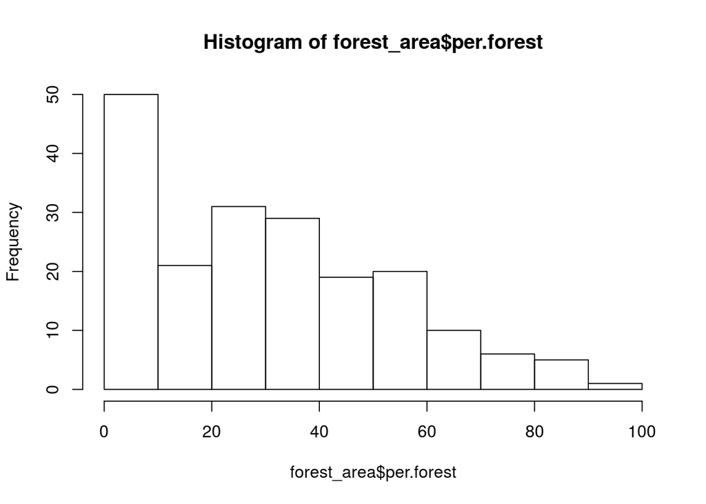

```r
hist(forest_area$per.forest)
```

Now find the median land area in our data frame. Just like `mean()`, the function you want is `median()`.

```r
median(forest_area$land.area.km)
```

```
## [1] 27065
```

The `$` operator is a much better way to subset a column of data than positional subsets, because we don’t have to memorize what position our column of interest is in (is it the 2nd column? The 4th?). This might seem trivial with 4 columns, but when you have 10, 20, or maybe 100 variables, the ability to refer to the column by name is a life saver.

Now we’re really going to spice things up - logical subsets! Earlier in the lesson we subset a vector based on a logical condition. We can also subset our entire data frame using the values of a single column.

What if we were interested in rows of data (observations) for only those countries with more than 80% forest cover?. We’ll need a logical subset of course! To show you how this works, first enter `forest_area$per.forest > 80` now.

```r
forest_area$per.forest > 80
```

```
##   [1] FALSE FALSE FALSE FALSE FALSE FALSE FALSE FALSE FALSE FALSE FALSE
##  [12] FALSE FALSE FALSE FALSE FALSE FALSE FALSE FALSE FALSE FALSE FALSE
##  [23] FALSE FALSE FALSE FALSE FALSE FALSE FALSE  TRUE FALSE FALSE FALSE
##  [34] FALSE FALSE FALSE FALSE FALSE FALSE FALSE  TRUE FALSE FALSE FALSE
##  [45] FALSE FALSE FALSE FALSE FALSE FALSE FALSE FALSE FALSE FALSE FALSE
##  [56] FALSE FALSE FALSE FALSE FALSE FALSE FALSE FALSE FALSE FALSE FALSE
##  [67] FALSE FALSE FALSE FALSE FALSE FALSE FALSE FALSE FALSE FALSE FALSE
##  [78] FALSE FALSE FALSE FALSE FALSE FALSE FALSE FALSE FALSE FALSE FALSE
##  [89] FALSE FALSE FALSE FALSE FALSE FALSE FALSE FALSE FALSE FALSE FALSE
## [100] FALSE FALSE FALSE FALSE FALSE FALSE FALSE FALSE FALSE FALSE FALSE
## [111] FALSE FALSE FALSE FALSE FALSE FALSE FALSE FALSE FALSE FALSE FALSE
## [122] FALSE FALSE FALSE FALSE FALSE FALSE FALSE FALSE FALSE FALSE FALSE
## [133] FALSE FALSE FALSE FALSE FALSE FALSE FALSE FALSE FALSE FALSE FALSE
## [144] FALSE FALSE FALSE FALSE FALSE FALSE FALSE FALSE FALSE FALSE FALSE
## [155] FALSE FALSE FALSE FALSE FALSE FALSE FALSE FALSE  TRUE FALSE FALSE
## [166] FALSE  TRUE  TRUE FALSE FALSE FALSE FALSE FALSE FALSE FALSE FALSE
## [177] FALSE FALSE FALSE FALSE FALSE FALSE FALSE  TRUE FALSE FALSE FALSE
## [188] FALSE FALSE FALSE FALSE FALSE
```

This logical vector can be passed as our row subset, such that R will only keep those rows which are TRUE in the vector. Lets subset our entire data frame with this vector by passing the logical statement we just entered as our row subset, and leaving the column subset blank (because we want to see all variables). Try it now.

```r
forest_area[forest_area$per.forest > 80,]
```

```
##     rank    country land.area.km per.forest
## 30    30      Gabon       227517      85.00
## 41    41   Suriname       147760      90.20
## 163  164 Micronesia          630      89.74
## 167  168 Seychelles          407      89.45
## 168  169      Palau          400      87.15
## 184  185     Tuvalu           23      89.12
```

Great work. Now subset the data frame for ranks above or equal to 20. To add an `equals to` to an inequality, just enter it as `>=` or `<=`.

```r
forest_area[forest_area$rank >= 20,]
```

```
##     rank                          country land.area.km per.forest
## 20    20                           Zambia       376309      50.00
## 21    21                         Tanzania       352570      37.22
## 22    22                            Sudan       327909      17.62
## 23    23                 Papua New Guinea       294370      63.60
## 24    24                           Sweden       280730      68.95
## 25    25                         Zimbabwe       259267      66.35
## 26    26                            Japan       253203      67.00
## 27    27                           France       246640      36.76
## 28    28                          Finland       233320      72.00
## 29    29         Central African Republic       227550      36.53
## 30    30                            Gabon       227517      85.00
## 31    31            Republic of the Congo       224710      65.70
## 32    32                           Turkey       216781      27.60
## 33    33                         Cameroon       212450      44.68
```

[output cut: 159 more lines]

We can even use logical subsets to zero in on specific observations using other functions. How might we find the country with the maximum percentage forest cover?

Use the max() function to find the maximum value in the per.forest column in our data frame.

```r
max(forest_area$per.forest)
```

```
## [1] 90.2
```

We can use this function to create a logical statement to check where along our column of values the percentage forest cover is equal to the maximum. When finding an equivalence (as opposed to an inequality), the operator is a double equals, `==`. Enter `forest_area$per.forest == max(forest_area$per.forest)` now.

```r
forest_area$per.forest == max(forest_area$per.forest)
```

```
##   [1] FALSE FALSE FALSE FALSE FALSE FALSE FALSE FALSE FALSE FALSE FALSE
##  [12] FALSE FALSE FALSE FALSE FALSE FALSE FALSE FALSE FALSE FALSE FALSE
##  [23] FALSE FALSE FALSE FALSE FALSE FALSE FALSE FALSE FALSE FALSE FALSE
##  [34] FALSE FALSE FALSE FALSE FALSE FALSE FALSE  TRUE FALSE FALSE FALSE
##  [45] FALSE FALSE FALSE FALSE FALSE FALSE FALSE FALSE FALSE FALSE FALSE
##  [56] FALSE FALSE FALSE FALSE FALSE FALSE FALSE FALSE FALSE FALSE FALSE
##  [67] FALSE FALSE FALSE FALSE FALSE FALSE FALSE FALSE FALSE FALSE FALSE
##  [78] FALSE FALSE FALSE FALSE FALSE FALSE FALSE FALSE FALSE FALSE FALSE
##  [89] FALSE FALSE FALSE FALSE FALSE FALSE FALSE FALSE FALSE FALSE FALSE
## [100] FALSE FALSE FALSE FALSE FALSE FALSE FALSE FALSE FALSE FALSE FALSE
## [111] FALSE FALSE FALSE FALSE FALSE FALSE FALSE FALSE FALSE FALSE FALSE
## [122] FALSE FALSE FALSE FALSE FALSE FALSE FALSE FALSE FALSE FALSE FALSE
## [133] FALSE FALSE FALSE FALSE FALSE FALSE FALSE FALSE FALSE FALSE FALSE
## [144] FALSE FALSE FALSE FALSE FALSE FALSE FALSE FALSE FALSE FALSE FALSE
## [155] FALSE FALSE FALSE FALSE FALSE FALSE FALSE FALSE FALSE FALSE FALSE
## [166] FALSE FALSE FALSE FALSE FALSE FALSE FALSE FALSE FALSE FALSE FALSE
## [177] FALSE FALSE FALSE FALSE FALSE FALSE FALSE FALSE FALSE FALSE FALSE
## [188] FALSE FALSE FALSE FALSE FALSE
```

This gives us a logical vector in which the single TRUE corresponds to the maximum percentage forest cover. Now use this logical statement to subset forest_area for just the maximum, remembering to select all columns.

```r
forest_area[forest_area$per.forest == max(forest_area$per.forest),]
```

```
##    rank  country land.area.km per.forest
## 41   41 Suriname       147760       90.2
```

This is a very powerful form of subsetting, letting us select observations in our data frame for desired ranges of values or specific conditions like maximum or minimum. Essentially any logical condition you can imagine.

Lets do one last subset for this lesson. This time, we want only the country name that has the minimum percentage forest cover.

Since we only want the country name, we’re only subsetting the country column of our data frame. You can access this with the `$` operator as usual. Because we’re only subsetting a single column, we only need a single subset in our brackets `[]` (i.e. we dont need a row and column). Try selecting the country name that has the minimum percentage forest cover now.

```r
forest_area$country[forest_area$per.forest == min(forest_area$per.forest)]
```

```
## [1] Qatar
## 191 Levels: Afghanistan Albania Algeria Andorra ...  Switzerland
```

Excellent work. You’ve now been introduced to subsets in 2 dimensions. It may seem tricky or confusing now, but with practice (and you will practice plenty), you’ll be subseting your data frames like a pro in no time.

Please submit the log of this lesson to Google Forms so that Simon may evaluate your progress.

1. As you wish

As you wish